# Анализ ситуации с убытками Procrastinate Pro+

Несколько прошлых месяцев бизнес развлекательного приложения `Procrastinate Pro+` постоянно несет убытки - в привлечение пользователей было вложено огромное количество денег, но убытки продолжают расти. Необходимо разобраться в причинах этой ситуации.

У меня в распоряжении есть лог сервера с данными о посещениях приложения новыми пользователями, зарегистрировавшимися в период `с 2019-05-01 по 2019-10-27`, выгрузка их покупок за этот период, а также статистика рекламных расходов. Мне предстоит изучить, как люди пользуются продуктом, когда они начинают покупать, сколько денег приносит каждый клиент, когда он окупается и какие факторы отричательно влияют на привлечение пользователей.

## Загрузка данных и подготовка их к анализу

Мой основной инструмент — `pandas`. Я подключаю эту библиотеку. Также подключаю библиотеки `seaborn`, `numpy`, `matplotlib`, `datetime` и `timedelta` - они понадобятся для моих исследований.

Дополнительно отключу предупреждения (библиотека `warnings`).

```python
import pandas as pd                # импорт библиотеки pandas
import numpy as np                 # импорт библиотеки numpy
from datetime import datetime, timedelta
import seaborn as sns
import matplotlib.pyplot as plt    # импорт библиотеки matplotlib
import warnings as wg              # импорт библиотеки warnings

wg.filterwarnings('ignore')
```

Далее осуществляю чтение файлов

- визиты - `visits_info_short.csv`
- заказы - `orders_info_short.csv`
- расходы - `costs_info_short.csv` из папки `/datasets` и сохраняю их. Вывожу на экран первые пять строк полученных таблиц.

```python
# чтение файлов с данными и сохранение в переменные в зависимости от расположения
try:
    visits = pd.read_csv('/Users/a4128/Documents/My_projects/05_App/visits.csv') # локальный путь
    orders = pd.read_csv('/Users/a4128/Documents/My_projects/05_App/orders.csv')
    costs = pd.read_csv('/Users/a4128/Documents/My_projects/05_App/costs.csv')
except:
    visits = pd.read_csv('/datasets/visits_info_short.csv') # серверный путь
    orders = pd.read_csv('/datasets/orders_info_short.csv')
    costs = pd.read_csv('/datasets/costs_info_short.csv')
display(visits.head(3))
print(visits.info())
display(orders.head(3))
print(orders.info())
display(costs.head(3))
print(costs.info())
# получение первых 3 строк таблиц и общая нформация об исходных данных
```

|  | User Id | Region | Device | Channel | Session Start | Session End |
| --- | --- | --- | --- | --- | --- | --- |
| 0 | 981449118918 | United States | iPhone | organic | 2019-05-01 02:36:01 | 2019-05-01 02:45:01 |
| 1 | 278965908054 | United States | iPhone | organic | 2019-05-01 04:46:31 | 2019-05-01 04:47:35 |
| 2 | 590706206550 | United States | Mac | organic | 2019-05-01 14:09:25 | 2019-05-01 15:32:08 |

```
<class 'pandas.core.frame.DataFrame'>
RangeIndex: 309901 entries, 0 to 309900
Data columns (total 6 columns):
User Id          309901 non-null int64
Region           309901 non-null object
Device           309901 non-null object
Channel          309901 non-null object
Session Start    309901 non-null object
Session End      309901 non-null object
dtypes: int64(1), object(5)
memory usage: 14.2+ MB
None
```

|  | User Id | Event Dt | Revenue |
| --- | --- | --- | --- |
| 0 | 188246423999 | 2019-05-01 23:09:52 | 4.99 |
| 1 | 174361394180 | 2019-05-01 12:24:04 | 4.99 |
| 2 | 529610067795 | 2019-05-01 11:34:04 | 4.99 |

```
<class 'pandas.core.frame.DataFrame'>
RangeIndex: 40212 entries, 0 to 40211
Data columns (total 3 columns):
User Id     40212 non-null int64
Event Dt    40212 non-null object
Revenue     40212 non-null float64
dtypes: float64(1), int64(1), object(1)
memory usage: 942.6+ KB
None
```

|  | dt | Channel | costs |
| --- | --- | --- | --- |
| 0 | 2019-05-01 | FaceBoom | 113.3 |
| 1 | 2019-05-02 | FaceBoom | 78.1 |
| 2 | 2019-05-03 | FaceBoom | 85.8 |

```
<class 'pandas.core.frame.DataFrame'>
RangeIndex: 1800 entries, 0 to 1799
Data columns (total 3 columns):
dt         1800 non-null object
Channel    1800 non-null object
costs      1800 non-null float64
dtypes: float64(1), object(2)
memory usage: 42.3+ KB
None
```

### Восстановление стиля названий столбцов

Для начала восстановлю стиль названий для тех колонок, где я обнаружила нарушения:

```python
#переименование столбцов

visits.columns = [x.lower().replace(' ', '_') for x in visits.columns.values]
orders.columns = [x.lower().replace(' ', '_') for x in orders.columns.values]
costs.columns = [x.lower().replace(' ', '_') for x in costs.columns.values]

#visits = visits.rename(columns={'User Id': 'user_id',
                           # 'Region': 'region',
                           # 'Device': 'device',
                           # 'Channel': 'channel',
                           # 'Session Start': 'session_start',
                           # 'Session End': 'session_end'})
#orders = orders.rename(columns={'User Id': 'user_id',
                           # 'Event Dt': 'event_dt',
                           # 'Revenue': 'revenue'})
#costs = costs.rename(columns={'Channel': 'channel'})

#проверка
print(visits.columns)
print(orders.columns)
print(costs.columns)
```

```
Index(['user_id', 'region', 'device', 'channel', 'session_start',
       'session_end'],
      dtype='object')
Index(['user_id', 'event_dt', 'revenue'], dtype='object')
Index(['dt', 'channel', 'costs'], dtype='object')
```

Теперь названия всех столбцы во всех таблицах в нижнем регистре и без пробелов.

### Приведение типов данных

Изменю типы данных в столбцах: `session_start`, `session_end` (таблица `visits`), `event_dt` (таблица `orders`) и `dt` (таблица `costs`).

```python
print('Исходный тип данных в столбцах:')
print('session_start -', visits['session_start'].dtypes)
print('session_end -', visits['session_end'].dtypes)
print('event_dt -', orders['event_dt'].dtypes)
print('dt -', costs['dt'].dtypes)

visits['session_start'] = pd.to_datetime(visits['session_start'])
visits['session_end'] = pd.to_datetime(visits['session_end'])
orders['event_dt'] = pd.to_datetime(orders['event_dt'])
costs['dt'] = pd.to_datetime(costs['dt']).dt.date

print()
print('Измененный тип данных в столбцах:')
print('session_start -', visits['session_start'].dtypes)
print('session_end -', visits['session_end'].dtypes)
print('event_dt -', orders['event_dt'].dtypes)
print('dt -', costs['dt'].dtypes)
```

```
Исходный тип данных в столбцах:
session_start - object
session_end - object
event_dt - object
dt - object

Измененный тип данных в столбцах:
session_start - datetime64[ns]
session_end - datetime64[ns]
event_dt - datetime64[ns]
dt - object
```

### Проверка на дубликаты

```python
print('Количнство явных дубликатов в датафрейме:')
print('visits -', visits.duplicated().sum())
print('orders -', orders.duplicated().sum())
print('costs -', costs.duplicated().sum())
```

```
Количнство явных дубликатов в датафрейме:
visits - 0
orders - 0
costs - 0
```

### Проверка на пропущенные значения

```python
print('Количнствопропущенных значений в датафрейме:')
print('visits -', visits.isna().sum().sort_values(ascending=False))
print()
print('orders -', orders.isna().sum().sort_values(ascending=False))
print()
print('costs -', costs.isna().sum().sort_values(ascending=False))
```

```
Количнствопропущенных значений в датафрейме:
visits - session_end      0
session_start    0
channel          0
device           0
region           0
user_id          0
dtype: int64

orders - revenue     0
event_dt    0
user_id     0
dtype: int64

costs - costs      0
channel    0
dt         0
dtype: int64
```

### Выводы по разделу

Данные получены, отображены и предварительно пранализированы.

Согласно документации к данным, таблицы содержат следующую информацию:

Таблица `visits_log_short` (лог сервера с информацией о посещениях сайта):

- `User Id` — уникальный идентификатор пользователя
- `Device` — категория устройства пользователя
- `Session start` — дата и время начала сессии
- `Session End` — дата и время окончания сессии
- `Channel` — идентификатор рекламного источника, из которого пришел пользователь
- `Region` - страна пользователя

Таблица `orders_log_short` (информация о заказах):

- `User Id` — уникальный id пользователя, который сделал заказ
- `Event Dt` — дата и время покупки
- `Revenue` — выручка

Таблица `costs_short` (информация о затратах на маркетинг):

- `Channel` — идентификатор рекламного источника
- `Dt` — дата
- `Costs` — затраты на этот рекламный источник в этот день

В результате предварительного анализа выявлено:

- во всех таблицах присутствует нарушение стиля названий (заглавные буквы, пробелы);
- некоторые типы данных не соответствуют логике (поля, содержащие даты, имеют тип `object`);
- в таблицах отсутствуют дубликаты;
- в таблицах отсутствуют пропуски в данных.

На этапе предобработки данных:

- исправлены нарушения в названиях столбцов,
- поля, содержащие даты, приведены к типу `datetime`.

## Задание функций расчета метрик

### Расчет LTV и ROI

`LTV`, или `Lifetime Value`, — это «пожизненная ценность» клиента, то есть общая сумма денег, которую один клиент в среднем приносит компании со всех своих покупок. В теории эта метрика включает все прошлые, нынешние и будущие покупки пользователя.

`ROI`, или `Return On Investment`, — окупаемость инвестиций. В экономике одного покупателя эта метрика показывает, на сколько процентов `LTV` превысил `CAC` (`CAC` или `Customer Acquisition Cost`, — стоимость привлечения одного клиента. Сумма денег, в которую компании обходится каждый новый клиент. В сущности, `CAC` — это инвестиции в маркетинг).

```python
# функция для расчёта LTV и ROI

def get_ltv(
    profiles,
    purchases,
    observation_date,
    horizon_days,
    dimensions=[],
    ignore_horizon=False,
):

    # исключаю пользователей, не «доживших» до горизонта анализа
    last_suitable_acquisition_date = observation_date
    if not ignore_horizon:
        last_suitable_acquisition_date = observation_date - timedelta(
            days=horizon_days - 1
        )
    result_raw = profiles.query('dt <= @last_suitable_acquisition_date')
    # добавляю данные о покупках в профили
    result_raw = result_raw.merge(
        purchases[['user_id', 'event_dt', 'revenue']], on='user_id', how='left'
    )
    # рассчитываю лайфтайм пользователя для каждой покупки
    result_raw['lifetime'] = (
        result_raw['event_dt'] - result_raw['first_ts']
    ).dt.days
    # группирую по cohort, если в dimensions ничего нет
    if len(dimensions) == 0:
        result_raw['cohort'] = 'All users'
        dimensions = dimensions + ['cohort']

    # функция группировки по желаемым признакам
    def group_by_dimensions(df, dims, horizon_days):
        # строим «треугольную» таблицу выручки
        result = df.pivot_table(
            index=dims, columns='lifetime', values='revenue', aggfunc='sum'
        )
        # нахожу сумму выручки с накоплением
        result = result.fillna(0).cumsum(axis=1)
        # вычисляю размеры когорт
        cohort_sizes = (
            df.groupby(dims)
            .agg({'user_id': 'nunique'})
            .rename(columns={'user_id': 'cohort_size'})
        )
        # объединяю размеры когорт и таблицу выручки
        result = cohort_sizes.merge(result, on=dims, how='left').fillna(0)
        # считаю LTV: делю каждую «ячейку» в строке на размер когорты
        result = result.div(result['cohort_size'], axis=0)
        # исключаю все лайфтаймы, превышающие горизонт анализа
        result = result[['cohort_size'] + list(range(horizon_days))]
        # восстанавливаю размеры когорт
        result['cohort_size'] = cohort_sizes

        # собираю датафрейм с данными пользователей и значениями CAC,
        # добавляя параметры из dimensions
        cac = df[['user_id', 'acquisition_cost'] + dims].drop_duplicates()

        # считаю средний CAC по параметрам из dimensions
        cac = (
            cac.groupby(dims)
            .agg({'acquisition_cost': 'mean'})
            .rename(columns={'acquisition_cost': 'cac'})
        )

        # считаю ROI: делю LTV на CAC
        roi = result.div(cac['cac'], axis=0)

        # удаляю строки с бесконечным ROI
        roi = roi[~roi['cohort_size'].isin([np.inf])]

        # восстанавливаю размеры когорт в таблице ROI
        roi['cohort_size'] = cohort_sizes

        # добавляю CAC в таблицу ROI
        roi['cac'] = cac['cac']

        # в финальной таблице оставляю размеры когорт, CAC
        # и ROI в лайфтаймы, не превышающие горизонт анализа
        roi = roi[['cohort_size', 'cac'] + list(range(horizon_days))]

        # возвращаю таблицы LTV и ROI
        return result, roi

    # получаю таблицы LTV и ROI
    result_grouped, roi_grouped = group_by_dimensions(
        result_raw, dimensions, horizon_days
    )

    # для таблиц динамики убираю 'cohort' из dimensions
    if 'cohort' in dimensions:
        dimensions = []

    # получаю таблицы динамики LTV и ROI
    result_in_time, roi_in_time = group_by_dimensions(
        result_raw, dimensions + ['dt'], horizon_days
    )

    return (
        result_raw,  # сырые данные
        result_grouped,  # таблица LTV
        result_in_time,  # таблица динамики LTV
        roi_grouped,  # таблица ROI
        roi_in_time,  # таблица динамики ROI
    )
```

### Расчет удержания

`Retention Rate` показывает, сколько пользователей из когорты относительно их изначального числа вернулись, то есть воспользовались продуктом или услугой, в последующие периоды.

```python
# функция для расчёта удержания

def get_retention(
    profiles,
    sessions,
    observation_date,
    horizon_days,
    dimensions=[],
    ignore_horizon=False,
):

    # добавляю столбец payer в передаваемый dimensions список
    dimensions = ['payer'] + dimensions

    # исключаю пользователей, не «доживших» до горизонта анализа
    last_suitable_acquisition_date = observation_date
    if not ignore_horizon:
        last_suitable_acquisition_date = observation_date - timedelta(
            days=horizon_days - 1
        )
    result_raw = profiles.query('dt <= @last_suitable_acquisition_date')

    # собираю «сырые» данные для расчёта удержания
    result_raw = result_raw.merge(
        sessions[['user_id', 'session_start']], on='user_id', how='left'
    )
    result_raw['lifetime'] = (
        result_raw['session_start'] - result_raw['first_ts']
    ).dt.days

    # функция для группировки таблицы по желаемым признакам
    def group_by_dimensions(df, dims, horizon_days):
        result = df.pivot_table(
            index=dims, columns='lifetime', values='user_id', aggfunc='nunique'
        )
        cohort_sizes = (
            df.groupby(dims)
            .agg({'user_id': 'nunique'})
            .rename(columns={'user_id': 'cohort_size'})
        )
        result = cohort_sizes.merge(result, on=dims, how='left').fillna(0)
        result = result.div(result['cohort_size'], axis=0)
        result = result[['cohort_size'] + list(range(horizon_days))]
        result['cohort_size'] = cohort_sizes
        return result

    # получаю таблицу удержания
    result_grouped = group_by_dimensions(result_raw, dimensions, horizon_days)

    # получаю таблицу динамики удержания
    result_in_time = group_by_dimensions(
        result_raw, dimensions + ['dt'], horizon_days
    )

    # возвращаю обе таблицы и сырые данные
    return result_raw, result_grouped, result_in_time
```

### Расчет конверсии

`Conversion Rate` - конверсия, или коэффициент конверсии (`CR`), — это процент пользователей когорты, изменившие статус с неплатящих пользователей в приложении в платящие.

```python
# функция для расчёта конверсии

def get_conversion(
    profiles,
    purchases,
    observation_date,
    horizon_days,
    dimensions=[],
    ignore_horizon=False,
):

    # исключаю пользователей, не «доживших» до горизонта анализа
    last_suitable_acquisition_date = observation_date
    if not ignore_horizon:
        last_suitable_acquisition_date = observation_date - timedelta(
            days=horizon_days - 1
        )
    result_raw = profiles.query('dt <= @last_suitable_acquisition_date')

    # определяю дату и время первой покупки для каждого пользователя
    first_purchases = (
        purchases.sort_values(by=['user_id', 'event_dt'])
        .groupby('user_id')
        .agg({'event_dt': 'first'})
        .reset_index()
    )

    # добавляю данные о покупках в профили
    result_raw = result_raw.merge(
        first_purchases[['user_id', 'event_dt']], on='user_id', how='left'
    )

    # рассчитываю лайфтайм для каждой покупки
    result_raw['lifetime'] = (
        result_raw['event_dt'] - result_raw['first_ts']
    ).dt.days

    # группирую по cohort, если в dimensions ничего нет
    if len(dimensions) == 0:
        result_raw['cohort'] = 'All users'
        dimensions = dimensions + ['cohort']

    # функция для группировки таблицы по желаемым признакам
    def group_by_dimensions(df, dims, horizon_days):
        result = df.pivot_table(
            index=dims, columns='lifetime', values='user_id', aggfunc='nunique'
        )
        result = result.fillna(0).cumsum(axis = 1)
        cohort_sizes = (
            df.groupby(dims)
            .agg({'user_id': 'nunique'})
            .rename(columns={'user_id': 'cohort_size'})
        )
        result = cohort_sizes.merge(result, on=dims, how='left').fillna(0)
        # делю каждую «ячейку» в строке на размер когорты
        # и получаю conversion rate
        result = result.div(result['cohort_size'], axis=0)
        result = result[['cohort_size'] + list(range(horizon_days))]
        result['cohort_size'] = cohort_sizes
        return result

    # получаю таблицу конверсии
    result_grouped = group_by_dimensions(result_raw, dimensions, horizon_days)

    # для таблицы динамики конверсии убираю 'cohort' из dimensions
    if 'cohort' in dimensions:
        dimensions = []

    # получаю таблицу динамики конверсии
    result_in_time = group_by_dimensions(
        result_raw, dimensions + ['dt'], horizon_days
    )

    # возвращаю обе таблицы и сырые данные
    return result_raw, result_grouped, result_in_time
```

## Задание функций визуализации

### Визуализация LTV и ROI

```python
# функция для сглаживания фрейма

def filter_data(df, window):
    # для каждого столбца применяю скользящее среднее
    for column in df.columns.values:
        df[column] = df[column].rolling(window).mean()
    return df

# функция для визуализации LTV и ROI

def plot_ltv_roi(ltv, ltv_history, roi, roi_history, horizon, window=7):

    # задаю сетку отрисовки графиков
    plt.figure(figsize=(20, 10))

    # из таблицы ltv исключаю размеры когорт
    ltv = ltv.drop(columns=['cohort_size'])
    # в таблице динамики ltv оставляю только нужный лайфтайм
    ltv_history = ltv_history.drop(columns=['cohort_size'])[[horizon - 1]]

    # стоимость привлечения запишу в отдельный фрейм
    cac_history = roi_history[['cac']]

    # из таблицы roi исключаю размеры когорт и cac
    roi = roi.drop(columns=['cohort_size', 'cac'])
    # в таблице динамики roi оставляю только нужный лайфтайм
    roi_history = roi_history.drop(columns=['cohort_size', 'cac'])[
        [horizon - 1]
    ]

    # первый график — кривые ltv
    ax1 = plt.subplot(2, 3, 1)
    ltv.T.plot(grid=True, ax=ax1)
    plt.legend()
    plt.xlabel('Лайфтайм')
    plt.title('LTV')

    # второй график — динамика ltv
    ax2 = plt.subplot(2, 3, 2, sharey=ax1)
    # столбцами сводной таблицы станут все столбцы индекса, кроме даты
    columns = [name for name in ltv_history.index.names if name not in ['dt']]
    filtered_data = ltv_history.pivot_table(
        index='dt', columns=columns, values=horizon - 1, aggfunc='mean'
    )
    filter_data(filtered_data, window).plot(grid=True, ax=ax2)
    plt.xlabel('Дата привлечения')
    plt.title('Динамика LTV пользователей на {}-й день'.format(horizon))

    # третий график — динамика cac
    ax3 = plt.subplot(2, 3, 3, sharey=ax1)
    # столбцами сводной таблицы станут все столбцы индекса, кроме даты
    columns = [name for name in cac_history.index.names if name not in ['dt']]
    filtered_data = cac_history.pivot_table(
        index='dt', columns=columns, values='cac', aggfunc='mean'
    )
    filter_data(filtered_data, window).plot(grid=True, ax=ax3)
    plt.xlabel('Дата привлечения')
    plt.title('Динамика стоимости привлечения пользователей')

    # четвёртый график — кривые roi
    ax4 = plt.subplot(2, 3, 4)
    roi.T.plot(grid=True, ax=ax4)
    plt.axhline(y=1, color='red', linestyle='--', label='Уровень окупаемости')
    plt.legend()
    plt.xlabel('Лайфтайм')
    plt.title('ROI')

    # пятый график — динамика roi
    ax5 = plt.subplot(2, 3, 5, sharey=ax4)
    # столбцами сводной таблицы станут все столбцы индекса, кроме даты
    columns = [name for name in roi_history.index.names if name not in ['dt']]
    filtered_data = roi_history.pivot_table(
        index='dt', columns=columns, values=horizon - 1, aggfunc='mean'
    )
    filter_data(filtered_data, window).plot(grid=True, ax=ax5)
    plt.axhline(y=1, color='red', linestyle='--', label='Уровень окупаемости')
    plt.xlabel('Дата привлечения')
    plt.title('Динамика ROI пользователей на {}-й день'.format(horizon))

    plt.tight_layout()
    plt.show()
```

### Визуализация удержания

```python
# функция для визуализации удержания

def plot_retention(retention, retention_history, horizon, window=7):

    # задаю размер сетки для графиков
    plt.figure(figsize=(15, 10))

    # исключаю размеры когорт и удержание первого дня
    retention = retention.drop(columns=['cohort_size', 0])
    # в таблице динамики оставляю только нужный лайфтайм
    retention_history = retention_history.drop(columns=['cohort_size'])[
        [horizon - 1]
    ]

    # если в индексах таблицы удержания только payer,
    # добавляю второй признак — cohort
    if retention.index.nlevels == 1:
        retention['cohort'] = 'All users'
        retention = retention.reset_index().set_index(['cohort', 'payer'])

    # в таблице графиков — два столбца и две строки, четыре ячейки
    # в первой строю кривые удержания платящих пользователей
    ax1 = plt.subplot(2, 2, 1)
    retention.query('payer == True').droplevel('payer').T.plot(
        grid=True, ax=ax1
    )
    plt.legend()
    plt.xlabel('Лайфтайм')
    plt.title('Удержание платящих пользователей')

    # во второй ячейке строю кривые удержания неплатящих
    # вертикальная ось — от графика из первой ячейки
    ax2 = plt.subplot(2, 2, 2, sharey=ax1)
    retention.query('payer == False').droplevel('payer').T.plot(
        grid=True, ax=ax2
    )
    plt.legend()
    plt.xlabel('Лайфтайм')
    plt.title('Удержание неплатящих пользователей')

    # в третьей ячейке — динамика удержания платящих
    ax3 = plt.subplot(2, 2, 3)
    # получаю названия столбцов для сводной таблицы
    columns = [
        name
        for name in retention_history.index.names
        if name not in ['dt', 'payer']
    ]
    # фильтрую данные и строим график
    filtered_data = retention_history.query('payer == True').pivot_table(
        index='dt', columns=columns, values=horizon - 1, aggfunc='mean'
    )
    filter_data(filtered_data, window).plot(grid=True, ax=ax3)
    plt.xlabel('Дата привлечения')
    plt.title(
        'Динамика удержания платящих пользователей на {}-й день'.format(
            horizon
        )
    )

    # в чётвертой ячейке — динамика удержания неплатящих
    ax4 = plt.subplot(2, 2, 4, sharey=ax3)
    # фильтрую данные и строю график
    filtered_data = retention_history.query('payer == False').pivot_table(
        index='dt', columns=columns, values=horizon - 1, aggfunc='mean'
    )
    filter_data(filtered_data, window).plot(grid=True, ax=ax4)
    plt.xlabel('Дата привлечения')
    plt.title(
        'Динамика удержания неплатящих пользователей на {}-й день'.format(
            horizon
        )
    )

    plt.tight_layout()
    plt.show()
```

### Визуализация конверсии

```python
# функция для визуализации конверсии

def plot_conversion(conversion, conversion_history, horizon, window=7):

    # задаю размер сетки для графиков
    plt.figure(figsize=(15, 5))

    # исключаю размеры когорт
    conversion = conversion.drop(columns=['cohort_size'])
    # в таблице динамики оставляю только нужный лайфтайм
    conversion_history = conversion_history.drop(columns=['cohort_size'])[
        [horizon - 1]
    ]

    # первый график — кривые конверсии
    ax1 = plt.subplot(1, 2, 1)
    conversion.T.plot(grid=True, ax=ax1)
    plt.legend()
    plt.xlabel('Лайфтайм')
    plt.title('Конверсия пользователей')

    # второй график — динамика конверсии
    ax2 = plt.subplot(1, 2, 2, sharey=ax1)
    columns = [
        # столбцами сводной таблицы станут все столбцы индекса, кроме даты
        name for name in conversion_history.index.names if name not in ['dt']
    ]
    filtered_data = conversion_history.pivot_table(
        index='dt', columns=columns, values=horizon - 1, aggfunc='mean'
    )
    filter_data(filtered_data, window).plot(grid=True, ax=ax2)
    plt.xlabel('Дата привлечения')
    plt.title('Динамика конверсии пользователей на {}-й день'.format(horizon))

    plt.tight_layout()
    plt.show()
```

## Исследовательский анализ данных

### Создание пользовательских профилей

Создам пользовательские профили.

```python
# функция для создания пользовательских профилей

def get_profiles(sessions, orders, costs):

    # нахожу параметры первых посещений
    profiles = (
        sessions.sort_values(by=['user_id', 'session_start'])
        .groupby('user_id')
        .agg(
            {
                'session_start': 'first',
                'channel': 'first',
                'device': 'first',
                'region': 'first',
            }
        )
        .rename(columns={'session_start': 'first_ts'})
        .reset_index()
    )

    # для когортного анализа определяю дату первого посещения
    # и первый день месяца, в который это посещение произошло
    profiles['dt'] = profiles['first_ts'].dt.date
    profiles['month'] = profiles['first_ts'].astype('datetime64[M]')

    # добавляю признак платящих пользователей
    profiles['payer'] = profiles['user_id'].isin(orders['user_id'].unique())

    # считаю количество уникальных пользователей
    # с одинаковыми источником и датой привлечения
    new_users = (
        profiles.groupby(['dt', 'channel'])
        .agg({'user_id': 'nunique'})
        .rename(columns={'user_id': 'unique_users'})
        .reset_index()
    )

    # объединяю траты на рекламу и число привлечённых пользователей
    costs = costs.merge(new_users, on=['dt', 'channel'], how='left')

    # делю рекламные расходы на число привлечённых пользователей
    costs['acquisition_cost'] = costs['costs'] / costs['unique_users']

    # добавляю стоимость привлечения в профили
    profiles = profiles.merge(
        costs[['dt', 'channel', 'acquisition_cost']],
        on=['dt', 'channel'],
        how='left',
    )

    # стоимость привлечения органических пользователей равна нулю
    profiles['acquisition_cost'] = profiles['acquisition_cost'].fillna(0)

    return profiles
```

Получу профили пользователей. Для этого вызову функцию `get_profiles()`, передав ей данные о посещениях, покупках и тратах на рекламу развлекательного приложения `Procrastinate Pro+`.

```python
# получаю профили пользователей
profiles = get_profiles(visits, orders, costs)
display(profiles.head())
```

|  | user_id | first_ts | channel | device | region | dt | month | payer | acquisition_cost |
| --- | --- | --- | --- | --- | --- | --- | --- | --- | --- |
| 0 | 599326 | 2019-05-07 20:58:57 | FaceBoom | Mac | United States | 2019-05-07 | 2019-05-01 | True | 1.088172 |
| 1 | 4919697 | 2019-07-09 12:46:07 | FaceBoom | iPhone | United States | 2019-07-09 | 2019-07-01 | False | 1.107237 |
| 2 | 6085896 | 2019-10-01 09:58:33 | organic | iPhone | France | 2019-10-01 | 2019-10-01 | False | 0.000000 |
| 3 | 22593348 | 2019-08-22 21:35:48 | AdNonSense | PC | Germany | 2019-08-22 | 2019-08-01 | False | 0.988235 |
| 4 | 31989216 | 2019-10-02 00:07:44 | YRabbit | iPhone | United States | 2019-10-02 | 2019-10-01 | False | 0.230769 |

Определю минимальную и максимальную даты привлечения пользователей.

```python
print('Минимальная дата привелечения -', min(profiles['dt']))
print('Максимальная дата привелечения -', max(profiles['dt']))
```

```
Минимальная дата привелечения - 2019-05-01
Максимальная дата привелечения - 2019-10-27
```

Определю, из каких стран приходят посетители, а также какие страны дают больше всего платящих пользователей.

```python
print('Все страны, из которых приходят посетители:')
print(profiles['region'].unique())
print()
regions = ((profiles
           .query('payer == True')
           .groupby('region')['user_id']
           .count()) / (profiles
                        .groupby('region')['user_id']
                        .count())).sort_values(ascending=False)

#print('Доля платящих пользователей в каждой стране:')
print(regions)
```

```
Все страны, из которых приходят посетители:
['United States' 'France' 'Germany' 'UK']

region
United States    0.069019
Germany          0.041119
UK               0.039829
France           0.037994
Name: user_id, dtype: float64
```

Определю, какими устройствами пользуются посетители приложения, а также с каких устройств чаще всего заходят платящие пользователи.

```python
print('Все устройства, с которых посетители заходят в приложение:')
print(profiles['device'].unique())
print()
devices = ((profiles
           .query('payer == True')
           .groupby('device')['user_id']
           .count()) / (profiles
                        .groupby('device')['user_id']
                        .count())).sort_values(ascending=False)

print('Доля платящих для пользователей каждого устройства:')
print(devices)
```

```
Все устройства, с которых посетители заходят в приложение:
['Mac' 'iPhone' 'PC' 'Android']

Доля платящих для пользователей каждого устройства:
device
Mac        0.063644
iPhone     0.062079
Android    0.058518
PC         0.050468
Name: user_id, dtype: float64
```

Определю, по каким рекламным каналам шло привлечение пользователей, а также какие каналы приносят больше всего платящих пользователей.

```python
print('Все источники привлечения пользователей:')
print(profiles['channel'].unique())
print()
channels = ((profiles
           .query('payer == True')
           .groupby('channel')['user_id']
           .count()) / (profiles
                        .groupby('channel')['user_id']
                        .count())).sort_values(ascending=False)

print('Доля платящих пользователей по каждому каналу привлечения:')
print(channels)
```

```
Все источники привлечения пользователей:
['FaceBoom' 'organic' 'AdNonSense' 'YRabbit' 'MediaTornado'
 'RocketSuperAds' 'LeapBob' 'TipTop' 'WahooNetBanner' 'OppleCreativeMedia'
 'lambdaMediaAds']

Доля платящих пользователей по каждому каналу привлечения:
channel
FaceBoom              0.122049
AdNonSense            0.113402
lambdaMediaAds        0.104700
TipTop                0.096007
RocketSuperAds        0.079137
WahooNetBanner        0.052964
YRabbit               0.038265
MediaTornado          0.035747
LeapBob               0.030633
OppleCreativeMedia    0.027077
organic               0.020553
Name: user_id, dtype: float64
```

### Маркетинг

Посчитаю общую сумму расходов на маркетинг. Выясню, как траты распределены по источникам.

```python
print('Общая сумма расходов на маркетинг составила -', profiles['acquisition_cost'].sum().astype('int'))
```

```
Общая сумма расходов на маркетинг составила - 105497
```

```python
marketing_channels = (
    profiles
    .groupby('channel')
    .agg({'acquisition_cost': 'sum'})
    .sort_values(by='acquisition_cost', ascending=False))
marketing_channels['%'] = round((marketing_channels['acquisition_cost'] / marketing_channels['acquisition_cost'].sum()) * 100, 1)

print('Распределение трат по источникам:')
print(marketing_channels)
```

```
Распределение трат по источникам:
                    acquisition_cost     %
channel
TipTop                      54751.30  51.9
FaceBoom                    32445.60  30.8
WahooNetBanner               5151.00   4.9
AdNonSense                   3911.25   3.7
OppleCreativeMedia           2151.25   2.0
RocketSuperAds               1833.00   1.7
LeapBob                      1797.60   1.7
lambdaMediaAds               1557.60   1.5
MediaTornado                  954.48   0.9
YRabbit                       944.22   0.9
organic                         0.00   0.0
```

Построю диаграмму динамики суммарных трат на маркетинг:

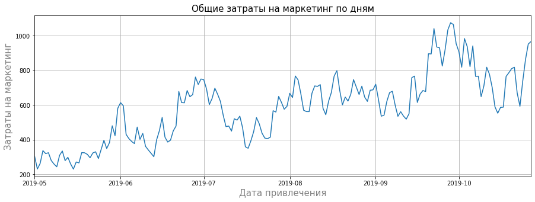

```python
profiles.groupby('dt')['acquisition_cost'].sum().plot(x='dt', y='acquisition_cost', figsize=(15, 5), grid=True, legend=None)
plt.xlabel('Дата привлечения', color='gray', fontsize=15)
plt.ylabel('Затраты на маркетинг', color='gray', fontsize=15)
plt.title('Общие затраты на маркетинг по дням', fontsize=15)
plt.show();
```

```python
#profiles.plot(x='dt', y='acquisition_cost', figsize=(15, 5), grid=True, legend=None)
#plt.xlabel('Дата привлечения', color='gray', fontsize=15)
#plt.ylabel('Затраты на маркетинг', color='gray', fontsize=15)
#plt.title('Общие затраты на маркетинг по дням', fontsize=15)
#plt.show();
```

Построю диаграмму динамики трат на маркетинг в зависимости от канала привелечения:

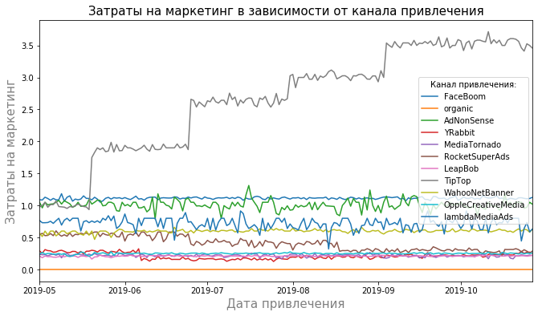

```python
channels = profiles['channel'].unique()

fig, ax = plt.subplots()

for element in channels:
    profiles[profiles['channel'] == element].plot.line(x='dt',
                                                       y='acquisition_cost',
                                                       #legend=False,
                                                       ax=ax,
                                                       figsize=(11, 6),
                                                       label=element
                                                      )
plt.xlabel('Дата привлечения', color='gray', fontsize=15)
plt.ylabel('Затраты на маркетинг', color='gray', fontsize=15)
plt.title('Затраты на маркетинг в зависимости от канала привлечения', fontsize=15)
plt.legend(title='Канал привлечения:', loc='center right');
```

Рассчитаю, сколько в среднем стоило привлечение одного пользователя из каждого источника (средний `CAC` на одного пользователя для каждого источника трафика) и для всего проекта.

```python
cac = round(profiles['acquisition_cost'].mean(), 3)
cac_channel = (round(profiles
                    .groupby(['channel'])['acquisition_cost']
                    .mean()
                    .sort_values(ascending=False), 3))
print('Средняя стоимость привлечения одного пользователя составляет:')
print(cac)
print()
print('Средняя стоимость привлечения одного пользователя в зависимости от рекламного источника:')
print()
print(cac_channel)
```

```
Средняя стоимость привлечения одного пользователя составляет:
0.703

Средняя стоимость привлечения одного пользователя в зависимости от рекламного источника:

channel
TipTop                2.799
FaceBoom              1.113
AdNonSense            1.008
lambdaMediaAds        0.725
WahooNetBanner        0.602
RocketSuperAds        0.412
OppleCreativeMedia    0.250
YRabbit               0.219
MediaTornado          0.219
LeapBob               0.210
organic               0.000
Name: acquisition_cost, dtype: float64
```

Построю диаграмму динамики привлечения пользователей по месяцам:

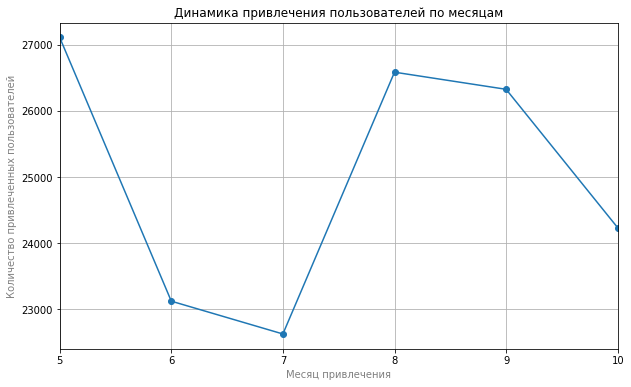

```python
profiles['dt'] = pd.to_datetime(profiles['dt'])
profiles.groupby(profiles['dt'].dt.month)['user_id'].count().plot(marker='o',
                                                                  grid=True,
                                                                  figsize=(10, 6))
plt.xlabel('Месяц привлечения', color='gray')
plt.ylabel('Количество привлеченных пользователей', color='gray')
plt.title('Динамика привлечения пользователей по месяцам');
```

В результате анализа маркетинга за последние 6 месяцев можно сделать следующие **промежуточные выводы**:

- общая сумма расходов на маркетинг составила 105497;
- больше половины этих расходов почти 52%, а именно 54751 потрачено на рекламный канал `TipTop`;
- также значительную часть расходов (почти 31%) составили расходы на канал `FaceBoom`;
- все остальные каналы привлечения пользователей составляют не более 5% от общих расходов на маркетинг;
- с каждым месяцем общие расходы н маркетинг возрастают;
- причиной возрастания трат является помесячное увеличение расходов на рекламный канал `TipTop`;
- ежемесячные траты на все остальные каналы привлечения остаются неизменными с течением времени;
- средняя стоимость привлечения одного пользователя составляет 0.703;
- средняя стоимость привлечения одного пользователя с канала `TipTop` превышает среднюю стоимость привлечения почти вчетверо;
- динамика привлечения пользователей отрицательная - в мае (на момент начала анализа) привлеченных пользователей было больше, чем во все последующие месяцы, это при ежемесячном увеличении расходов на рекламу, что говорит о неэффективности маркетинговых действий за последние полгода.

### Оценка окупаемости рекламы для привлечения пользователей

Буду считать, что на календаре 1 ноября 2019 года, а в бизнес-плане заложено, что пользователи должны окупаться не позднее чем через две недели после привлечения.

```python
observation_date = datetime(2019, 11, 1).date()  # момент анализа
horizon_days = 14  # горизонт анализа
```

Иключу из анализа органических пользователей, т.е. пользователей, которые совершили переход на ресурс с помощью поисковых систем (если пользователю нужна конкретная информация, он вводит соответствующий запрос в поисковую строку), т.к. в этом разделе я буду рассчитывать именно окупаемость рекламный кампаний.

```python
profiles = profiles[profiles['channel'] != 'organic']
```

#### Общая окупаемость

Для начала оценю общую ситуацию. Используя графики `LTV`, `ROI` и `CAC`, проанализирую окупаемость рекламы. Рассчитаю и визуализирую `LTV` и `ROI`, вызвав функции `get_ltv_roi()` и `plot_ltv_roi()`.

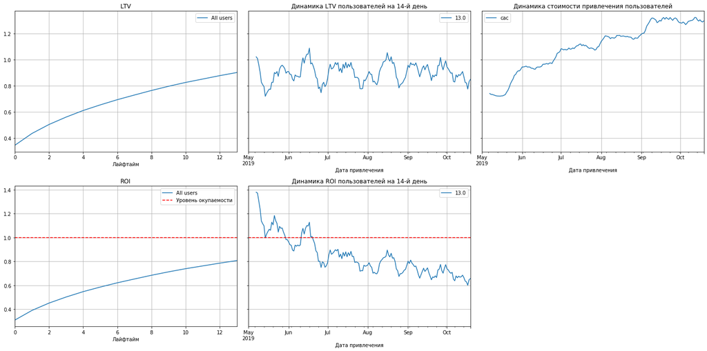

```python
# считаем LTV и ROI
ltv_raw, ltv_grouped, ltv_history, roi_grouped, roi_history = get_ltv(
    profiles, orders, observation_date, horizon_days
)

# строим графики
plot_ltv_roi(ltv_grouped, ltv_history, roi_grouped, roi_history, horizon_days)
```

По полученным графикам можно утверждать, что:

- реклама не окупается. Окупаемость инвестиций (`ROI`) по окончании двух недель активного маркетинга — около 80% и динамика отрицательная.
- стоимость привлечения одного клиента (`CAC`) с течением времени увеличивается, соответственно увеличивается рекламный бюджет.
- показатель «пожизненная ценность» клиента (`LTV`) достаточно стабилен, значит, дело не в ухудшении качества пользователей.

Чтобы разобраться в причинах неокупаемости рекламных кампаний, необходимо пройти по всем доступным характеристикам пользователей — региону, источнику и устройству первого посещения.

#### Окупаемость по регионам

Начну с разбивки по странам: передам параметру `dimensions` столбец `region`.

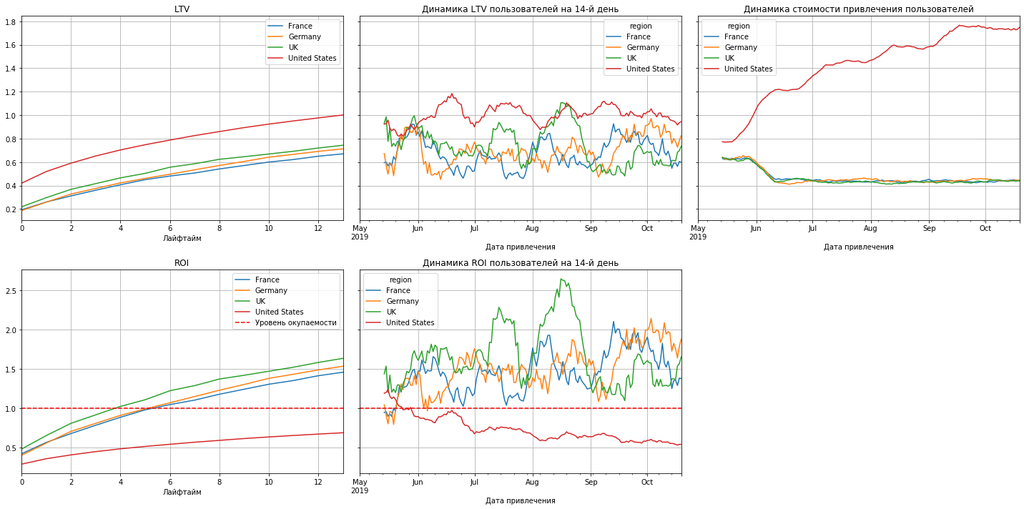

```python
# проверю окупаемость с разбивкой по странам

dimensions = ['region']

ltv_raw, ltv_grouped, ltv_history, roi_grouped, roi_history = get_ltv(
    profiles, orders, observation_date, horizon_days, dimensions=dimensions
)

plot_ltv_roi(
    ltv_grouped, ltv_history, roi_grouped, roi_history, horizon_days, window=14
)
```

При проведении анализа с разбивкой по странам, можно сделать следующие выводы:

- при сильном увеличении стоимости привлечения (`CAC`) пользователей в США, окупаемость в этой стране остается на порядок ниже, чем у остальных стран, которые тратят на рекламу много меньше и у которых с течением времени стоимость привлечения пользователей снижается;
- в Великобритании, Франции и Германии окупаемость рекламных затрат (`ROI`) происходит примерно на 4-5 день после проведения маркетинговых мероприятий, в США же показатель окупаемости на 14 день составляет всего около 60%;
- динамика окупаемости для США - отрицательна, в остальных странах показатель стабилен;
- показатель «пожизненная ценность» клиента (`LTV`) стабильно повышается во всех странах.

Пользователи из Великобритании, Франции и Германии стабильно окупаются, а вот из Америки — нет. Необходимо выяснить, в чём причина: в низкой конверсии или низком удержании. Посчитаю и визуализирую конверсию, вызвав функции `get_conversion()` и `plot_conversion()`.

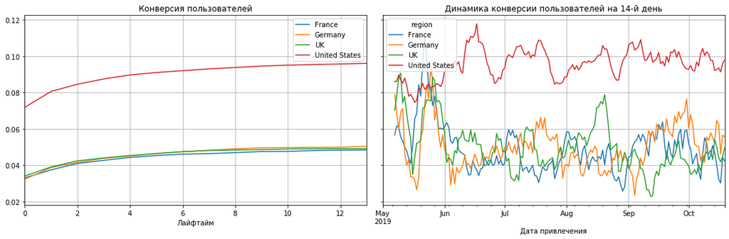

```python
# строю конверсию с разбивкой по странам

conversion_raw, conversion_grouped, conversion_history = get_conversion(
    profiles, orders, observation_date, horizon_days, dimensions=dimensions
)

plot_conversion(conversion_grouped, conversion_history, horizon_days)
```

Судя по графикам, американские пользователи конвертируются очень хорошо, причём постоянно и даже лучше европейских стран. Видимо, дело в удержании. Вызову функции `get_retention()` и `plot_retention()`, чтобы рассчитать и отразить на графиках этот показатель.

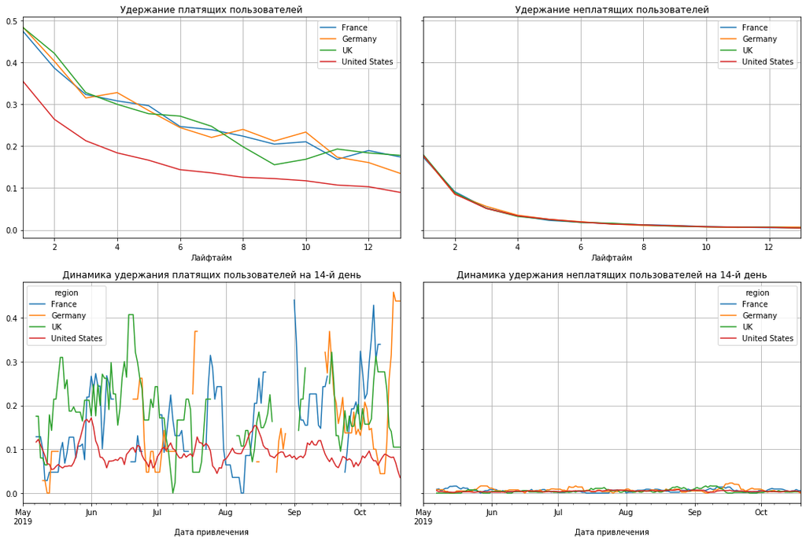

```python
# строю удержание с разбивкой по странам

retention_raw, retention_grouped, retention_history = get_retention(
    profiles, visits, observation_date, horizon_days, dimensions=dimensions
)

plot_retention(retention_grouped, retention_history, horizon_days)
```

Действительно, платящие пользователи из США стабильно плохо удерживаются. Для платящих пользователей в США удержание 14-го дня ниже, чем в остальных странах почти вдвое. Это очень низкий показатель. Скорее всего, причина в какой-нибудь технической проблеме.

#### Окупаемость по каналам привлечения

Теперь проверим источники привлечения (`channel`). Возможно, на окупаемость влияет неудачная реклама в каком-нибудь одном канале.

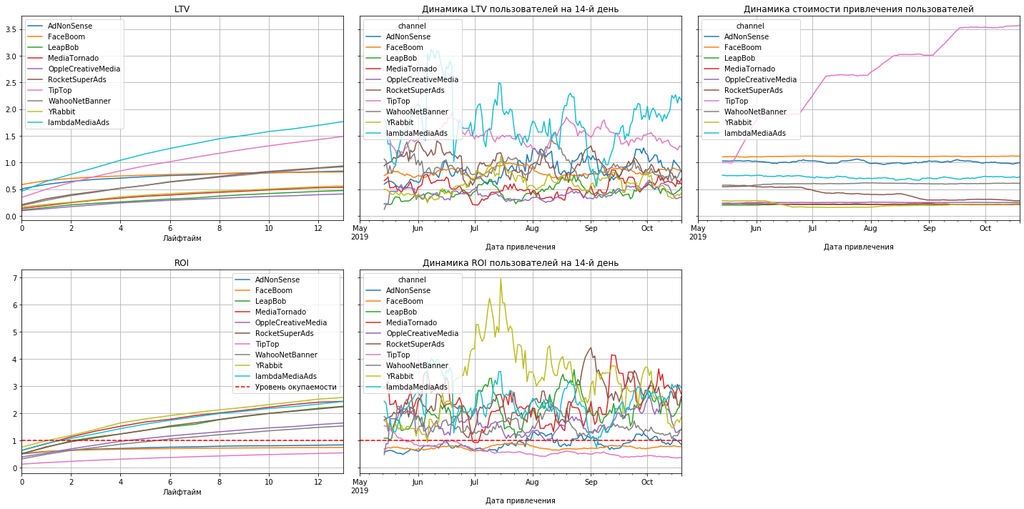

```python
# проверю окупаемость с разбивкой по источникам привлечения

dimensions = ['channel']

ltv_raw, ltv_grouped, ltv_history, roi_grouped, roi_history = get_ltv(
    profiles, orders, observation_date, horizon_days, dimensions=dimensions
)

plot_ltv_roi(
    ltv_grouped, ltv_history, roi_grouped, roi_history, horizon_days, window=14
)
```

При рассмотрении графиков окупаемости с разбиением по источникам привлечения пользователей можно заметить:

- сильно выбивается рекламный канал `TipTop`, затраты на который достаточно сильно растут от месяца к месяцу, в отличие от всех остальных каналов, для которых затраты остаются неизменными. Необходимо проверить адекватность вливания крупных сумм денег именно в этот источник привлечения пользователей.
- из всех источников привлечения не окупаются только 3 (`TipTop`. `AdNonSense` и `FaceBoom`), нужно выяснить, в чём причина: в низкой конверсии или низком удержании.

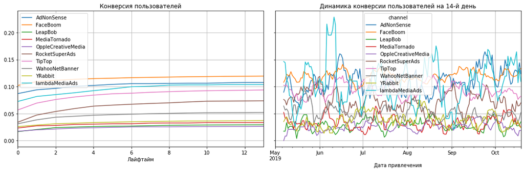

```python
# строю конверсию с разбивкой по каналам привлечения

conversion_raw, conversion_grouped, conversion_history = get_conversion(
    profiles, orders, observation_date, horizon_days, dimensions=dimensions
)

plot_conversion(conversion_grouped, conversion_history, horizon_days)
```

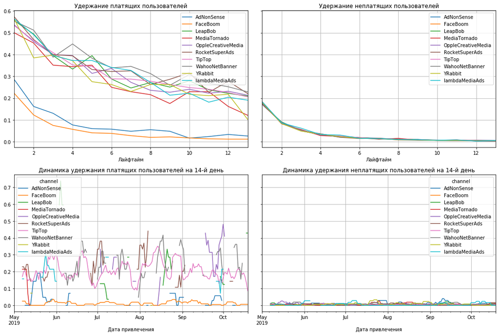

```python
# строю удержание с разбивкой по каналам привлечения

retention_raw, retention_grouped, retention_history = get_retention(
    profiles, visits, observation_date, horizon_days, dimensions=dimensions
)

plot_retention(retention_grouped, retention_history, horizon_days)
```

#### Окупаемость по устройствам

Перейду к устройствам.

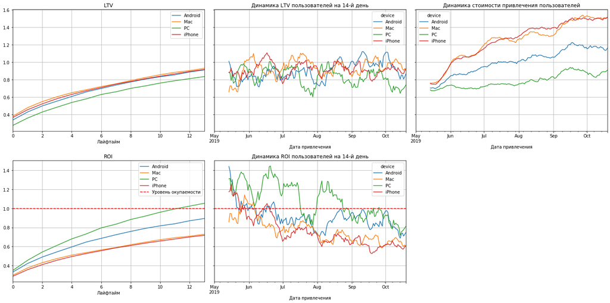

```python
# проверю окупаемость с разбивкой по устройствам

dimensions = ['device']

ltv_raw, ltv_grouped, ltv_history, roi_grouped, roi_history = get_ltv(
    profiles, orders, observation_date, horizon_days, dimensions=dimensions
)

plot_ltv_roi(
    ltv_grouped, ltv_history, roi_grouped, roi_history, horizon_days, window=14
)
```

Что касается окупаемости в зависимости от устройств, то здесь:

Расчитаю коэффиценты конверсии и удержания для пользователей различных устройств.

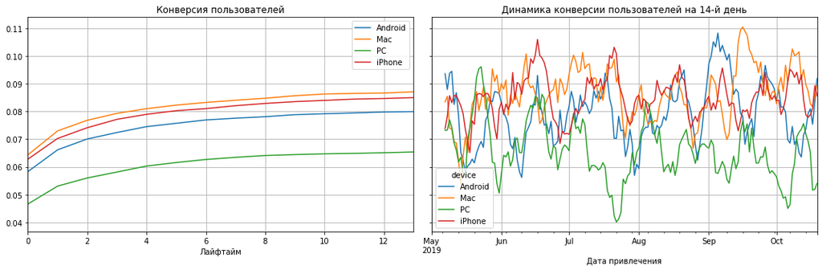

```python
# строю конверсию с разбивкой по каналам привлечения

conversion_raw, conversion_grouped, conversion_history = get_conversion(
    profiles, orders, observation_date, horizon_days, dimensions=dimensions
)

plot_conversion(conversion_grouped, conversion_history, horizon_days)
```

Обнаружена низкая конверсия для пользователей, использующих приложение на PC. Видимо, в полной версии приложения для PC недоработан блок, касающийся оплаты.

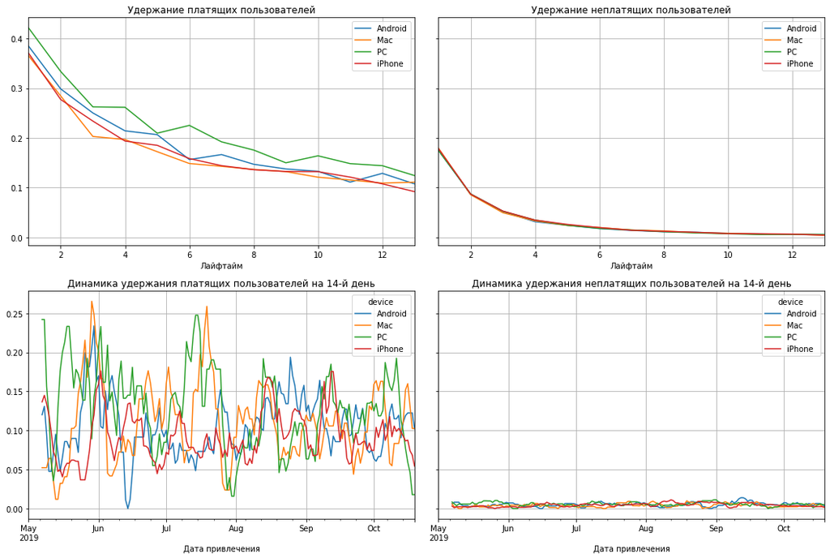

```python
# строю удержание с разбивкой по каналам привлечения

retention_raw, retention_grouped, retention_history = get_retention(
    profiles, visits, observation_date, horizon_days, dimensions=dimensions
)

plot_retention(retention_grouped, retention_history, horizon_days)
```

А вот с удержанием пользователей на любых устройствах все в полном порядке.

### Выводы по разделу

В результате проведенного анализа выявлено:

- реклама, направленная на привлечение пользователей в целом не окупается;
- платящие пользователи из США стабильно очень плохо удерживаются;
- на рекламный канал `TipTop` тратится половина всего рекламного бюджета, а окупаемость по истечении 14 дней не превышает 60%;
- также не окупаются рекламные каналы `AdNonSense` и `FaceBoom`, для которых по истечении 2-ух недель, коэффициент удержания стремится к 0;
- низкая конверсия для пользователей, использующих приложение на `PC`, это при том, что `PC` - единственное устройство, на котором рекламные кампании окупаются.

Проблемы окупаемости могут быть вызваны некоторыми факторами:

- техническими проблемами с приложением на территории США,
- неправильным выбором каналов, в которые активно производятся денежные вливания,
- возможно, в полной версии приложения для PC недоработан блок, касающийся оплаты, например, пользователи столкнулись с ошибкой при попытке оплаты заказа.

## Общие выводы

Несмотря на огромные вложения в рекламу, последние несколько месяцев компания `Procrastinate Pro+` терпит убытки. Задача стоит в анализе этой ситуации и выработке рекомендаций для отдела маркетинга для повышения эффективности бизнеса.

Мною получены данные о посещениях приложения `Procrastinate Pro+` новыми пользователями, зарегистрировавшимися в период `с 2019-05-01 по 2019-10-27`, выгрузка их покупок за этот период, а также статистика рекламных расходов.

В результате предварительного анализа обнаружены некоторые ошибки и недочеты в данных, а именно, нарушение стиля названий столбцов и нарушение логики в типах данных. Пропуски в данных и дубликаты обнаружены не были. Данные прошли предобработку, в результате чего все вышеуказанные недочеты были устранены.

На основании бизнес-плана горизонт окупаемости определен как 2 недели после привлечения пользователя. Анализ проводился на дату 1 ноября 2019 года. В анализ не включены пользователи органического трафика.

Проведен анализа маркетинга за последние полгода и сделаны следующие выводы:

- общая сумма расходов на маркетинг составила 105497;
- больше половины этих расходов почти 52%, а именно 54751 потрачено на рекламный канал `TipTop`;
- также значительную часть расходов (почти 31%) составили расходы на канал `FaceBoom`;
- все остальные каналы привлечения пользователей составляют не более 5% от общих расходов на маркетинг;
- с каждым месяцем общие расходы н маркетинг возрастают;
- причиной возрастания трат является помесячное увеличение расходов на рекламный канал `TipTop`;
- ежемесячные траты на все остальные каналы привлечения остаются неизменными с течением времени;
- средняя стоимость привлечения одного пользователя составляет 0.703;
- средняя стоимость привлечения одного пользователя с канала `TipTop` превышает среднюю стоимость привлечения почти вчетверо;
- динамика привлечения пользователей отрицательная - в мае (на момент начала анализа) привлеченных пользователей было больше, чем во все последующие месяцы, это при ежемесячном увеличении расходов на рекламу, что говорит о неэффективности маркетинговых действий за последние полгода.

Проведена оценка окупаемости рекламы, в результате которой выявлено:

- реклама, направленная на привлечение пользователей в целом не окупается. Окупаемость инвестиций по окончании двух недель активного маркетинга — около 80% и динамика отрицательная.
- стоимость привлечения одного клиента с течением времени увеличивается, соответственно увеличивается рекламный бюджет.
- качество пользователей остается на высоком уровне.
- платящие пользователи из США стабильно очень плохо удерживаются.
- на рекламный канал `TipTop` тратится половина всего рекламного бюджета, а окупаемость по истечении 14 дней не превышает 60%.
- также не окупаются рекламные каналы `AdNonSense` и `FaceBoom`, для которых по истечении 2-ух недель, коэффициент удержания стремится к 0.
- низкая конверсия для пользователей, использующих приложение на `PC`, это при том, что `PC` - единственное устройство, на котором рекламные кампании окупаются.

**Рекомендации для рекламного отдела по повышению эффективности маркетига**

Необходимо:

- срочно оповестить разработчиков о технических проблемах, возникающих у пользователей приложения на территории США;
- пересмотреть денежные вливания в рекламные источники `AdNonSense`, `FaceBoom` и `TipTop`, т.к. реклама в данных каналах за последние полгода оказалась неэффективной;
- проверить блок, касающийся оплаты, в приложении для устройств `PC`. Возможно пользователи сталкиваются с ошибкой при попытке оплаты заказа.